# Day 9: Data Analysis and Visualization

When we plot we need more libraries. You learned about matplot on Day 5, today we are going to build on what you learned and plot directly from pandas and I'm going to introduce seaborn.

## Goals for the day:

- Practice making a pivot table
- More understanding of groupby
- Introduction to seaborn
- Introduction to graph automation

## Functions Learned:

- Create a heatmap: `sns.heatmap()`
- Create a pairplot: `sns.pairplot()`
- Create a swarmplot: `sns.swarmplot()`
- Create a violinplot: `sns.violinplot`

I will not be able to finish the contents of this notebook but there are many useful tips here so I highly recommend that you complete on your own.

```python
# this line prints your matplot based plots in this notebook, in some computer without this line your graph will pop out as a window
%matplotlib inline

#call all the matplot libraries I may need
import matplotlib.pyplot as plt
from matplotlib import cm

#the usual
import pandas as pd
import numpy as np

#seaborn
import seaborn as sns; sns.set(color_codes=True)

#some libraries that allow is to run from stats
import scipy
from scipy import stats
```

## 0. Set Directory

```python
#this is the specific directory where the data we want to use is stored
datadirectory = '../data/'

#this is the directory where we want to store the data we finish analyzing
data_out_directory='../output/'
```

## Seaborn

For all the plot examples I am going to do below I am going to use [seaborn](https://seaborn.pydata.org/). You can look at the seaborn [gallery](https://seaborn.pydata.org/examples/index.html) and look at all the plotting options it offers.

## 14.Combination skills, Heatplots

I really want to know what the strongest pokemon type is for each generation and stats (Attack. Def. etc).

```python
# call in my data
pokemon=pd.read_csv(datadirectory+'Pokemon.csv')
pokemon.head()
```

|  | Number | Name | Type 1 | Type 2 | Total | HP | Attack | Defense | Sp. Atk | Sp. Def | Speed | Generation | Legendary |
| --- | --- | --- | --- | --- | --- | --- | --- | --- | --- | --- | --- | --- | --- |
| 0 | 1 | Bulbasaur | Grass | Poison | 318 | 45 | 49 | 49 | 65 | 65 | 45 | 1 | False |
| 1 | 2 | Ivysaur | Grass | Poison | 405 | 60 | 62 | 63 | 80 | 80 | 60 | 1 | False |
| 2 | 3 | Venusaur | Grass | Poison | 525 | 80 | 82 | 83 | 100 | 100 | 80 | 1 | False |
| 3 | 3 | VenusaurMega Venusaur | Grass | Poison | 625 | 80 | 100 | 123 | 122 | 120 | 80 | 1 | False |
| 4 | 4 | Charmander | Fire | NaN | 309 | 39 | 52 | 43 | 60 | 50 | 65 | 1 | False |

```python
### make a pivot table
data_subset=pokemon.pivot_table(values='Attack',index=['Type 1'],columns=['Generation'],aggfunc='min')
data_subset
```

| Generation Type 1 | 1 | 2 | 3 | 4 | 5 | 6 |
| --- | --- | --- | --- | --- | --- | --- |
| Bug | 20.0 | 10.0 | 30.0 | 25.0 | 40.0 | 22.0 |
| Dark | NaN | 60.0 | 55.0 | 90.0 | 50.0 | 54.0 |
| Dragon | 64.0 | NaN | 70.0 | 70.0 | 87.0 | 50.0 |
| Electric | 30.0 | 40.0 | 40.0 | 45.0 | 55.0 | 38.0 |
| Fairy | 45.0 | 20.0 | NaN | 50.0 | NaN | 38.0 |
| Fighting | 80.0 | 35.0 | 40.0 | 70.0 | 80.0 | 82.0 |
| Fire | 41.0 | 40.0 | 60.0 | 58.0 | 30.0 | 45.0 |
| Flying | NaN | NaN | NaN | NaN | 100.0 | 30.0 |
| Ghost | 35.0 | 60.0 | 40.0 | 50.0 | 30.0 | 66.0 |
| Grass | 40.0 | 30.0 | 40.0 | 30.0 | 27.0 | 61.0 |
| Ground | 50.0 | 60.0 | 40.0 | 72.0 | 66.0 | NaN |
| Ice | 50.0 | 30.0 | 40.0 | 60.0 | 50.0 | 69.0 |
| Normal | 5.0 | 10.0 | 20.0 | 5.0 | 50.0 | 36.0 |
| Poison | 45.0 | 90.0 | 43.0 | 50.0 | 50.0 | 60.0 |
| Psychic | 20.0 | 33.0 | 23.0 | 25.0 | 25.0 | 48.0 |
| Rock | 40.0 | 64.0 | 41.0 | 42.0 | 75.0 | 50.0 |
| Steel | NaN | 80.0 | 55.0 | 24.0 | 55.0 | 50.0 |
| Water | 10.0 | 20.0 | 15.0 | 20.0 | 40.0 | 53.0 |

## Coding Challenge

Make a function that makes a pivot table from the pokemon data. This function will allow me to use any aggregation function I want on any pokemon stats I want. The argument for this fuction should be stats_wanted and aggfun_wanted. The index is 'Type 1' and the columns 'Generation'.

```python
##### your code here
##hint use the code above and change what you need!

def get_summary(stats_wanted,aggfun_wanted):
    data_subset=pokemon.pivot_table(values=stats_wanted,index=['Type 1'],columns=['Generation'],aggfunc=aggfun_wanted)
    return data_subset


get_summary('Speed','max')
```

| Generation Type 1 | 1 | 2 | 3 | 4 | 5 | 6 |
| --- | --- | --- | --- | --- | --- | --- |
| Bug | 145.0 | 95.0 | 160.0 | 95.0 | 145.0 | 89.0 |
| Dark | NaN | 115.0 | 115.0 | 125.0 | 106.0 | 99.0 |
| Dragon | 80.0 | NaN | 120.0 | 102.0 | 97.0 | 95.0 |
| Electric | 140.0 | 115.0 | 135.0 | 95.0 | 116.0 | 109.0 |
| Fairy | 60.0 | 45.0 | NaN | 80.0 | NaN | 99.0 |
| Fighting | 95.0 | 70.0 | 100.0 | 112.0 | 105.0 | 118.0 |
| Fire | 105.0 | 100.0 | 100.0 | 108.0 | 101.0 | 126.0 |
| Flying | NaN | NaN | NaN | NaN | 121.0 | 123.0 |
| Ghost | 130.0 | 85.0 | 75.0 | 105.0 | 80.0 | 99.0 |
| Grass | 80.0 | 110.0 | 145.0 | 127.0 | 116.0 | 68.0 |
| Ground | 120.0 | 85.0 | 100.0 | 95.0 | 101.0 | NaN |
| Ice | 95.0 | 75.0 | 100.0 | 110.0 | 105.0 | 28.0 |
| Normal | 121.0 | 100.0 | 125.0 | 135.0 | 128.0 | 102.0 |
| Poison | 90.0 | 130.0 | 65.0 | 95.0 | 75.0 | 44.0 |
| Psychic | 150.0 | 110.0 | 180.0 | 115.0 | 114.0 | 104.0 |
| Rock | 150.0 | 71.0 | 75.0 | 58.0 | 110.0 | 110.0 |
| Steel | NaN | 70.0 | 110.0 | 90.0 | 108.0 | 75.0 |
| Water | 115.0 | 85.0 | 105.0 | 115.0 | 108.0 | 122.0 |

### Answer

```python
##make a fucntion that will aggregate my data based on whatever aggfun I want

def get_summary(stat_wanted,aggfun_wanted):
    data_subset=pokemon.pivot_table(values=stat_wanted,index=['Type 1'],columns=['Generation'],aggfunc=[aggfun_wanted])

    ###drop a level in the columns so the table looks nicer
    data_subset.columns=data_subset.columns.droplevel(0)
    return data_subset

get_summary('Attack','max')
```

| Generation Type 1 | 1 | 2 | 3 | 4 | 5 | 6 |
| --- | --- | --- | --- | --- | --- | --- |
| Bug | 155.0 | 185.0 | 90.0 | 94.0 | 135.0 | 52.0 |
| Dark | NaN | 95.0 | 150.0 | 125.0 | 125.0 | 131.0 |
| Dragon | 134.0 | NaN | 180.0 | 170.0 | 170.0 | 100.0 |
| Electric | 90.0 | 95.0 | 75.0 | 123.0 | 115.0 | 58.0 |
| Fairy | 70.0 | 120.0 | NaN | 50.0 | NaN | 131.0 |
| Fighting | 130.0 | 95.0 | 120.0 | 145.0 | 140.0 | 124.0 |
| Fire | 130.0 | 130.0 | 160.0 | 104.0 | 140.0 | 110.0 |
| Flying | NaN | NaN | NaN | NaN | 115.0 | 70.0 |
| Ghost | 65.0 | 60.0 | 165.0 | 120.0 | 55.0 | 110.0 |
| Grass | 105.0 | 82.0 | 130.0 | 132.0 | 98.0 | 107.0 |
| Ground | 130.0 | 120.0 | 180.0 | 140.0 | 145.0 | NaN |
| Ice | 85.0 | 100.0 | 120.0 | 130.0 | 110.0 | 117.0 |
| Normal | 125.0 | 130.0 | 160.0 | 160.0 | 128.0 | 80.0 |
| Poison | 105.0 | 90.0 | 100.0 | 106.0 | 95.0 | 75.0 |
| Psychic | 190.0 | 100.0 | 180.0 | 165.0 | 100.0 | 160.0 |
| Rock | 135.0 | 164.0 | 125.0 | 165.0 | 140.0 | 160.0 |
| Steel | NaN | 125.0 | 145.0 | 120.0 | 100.0 | 150.0 |
| Water | 155.0 | 105.0 | 150.0 | 120.0 | 108.0 | 95.0 |

```python
##make a fucntion that will aggregate my data based on whatever aggfun I want

def get_summary(stat_wanted,aggfun_wanted):
    data_subset=pokemon.pivot_table(values=stat_wanted,index=['Type 1'],columns=['Generation'],aggfunc=[aggfun_wanted])

  ###drop a level in the columns so the table looks nicer
  #data_subset.columns=data_subset.columns.droplevel(1)

  ## I can select more than one poke stat toplot, but from what I know with pivot you can only do one aggfunction
    return data_subset

get_summary(['Attack','Speed'],('max','min'))
```

| Generation Type 1 | max min Attack 1 | max min Attack 2 | max min Attack 3 | max min Attack 4 | max min Attack 5 | max min Attack 6 | max min Attack 1 | max min Attack 2 | max min Attack 3 | max min Attack 4 | max min ... | max min Speed 3 | max min Speed 4 | max min Speed 5 | max min Speed 6 | max min Speed 1 | max min Speed 2 | max min Speed 3 | max min Speed 4 | max min Speed 5 | max min Speed 6 |
| --- | --- | --- | --- | --- | --- | --- | --- | --- | --- | --- | --- | --- | --- | --- | --- | --- | --- | --- | --- | --- | --- |
| Bug | 155.0 | 185.0 | 90.0 | 94.0 | 135.0 | 52.0 | 20.0 | 10.0 | 30.0 | 25.0 | ... | 160.0 | 95.0 | 145.0 | 89.0 | 25.0 | 5.0 | 15.0 | 25.0 | 20.0 | 29.0 |
| Dark | NaN | 95.0 | 150.0 | 125.0 | 125.0 | 131.0 | NaN | 60.0 | 55.0 | 90.0 | ... | 115.0 | 125.0 | 106.0 | 99.0 | NaN | 65.0 | 20.0 | 71.0 | 38.0 | 45.0 |
| Dragon | 134.0 | NaN | 180.0 | 170.0 | 170.0 | 100.0 | 64.0 | NaN | 70.0 | 70.0 | ... | 120.0 | 102.0 | 97.0 | 95.0 | 50.0 | NaN | 50.0 | 42.0 | 48.0 | 40.0 |
| Electric | 90.0 | 95.0 | 75.0 | 123.0 | 115.0 | 58.0 | 30.0 | 40.0 | 40.0 | 45.0 | ... | 135.0 | 95.0 | 116.0 | 109.0 | 45.0 | 35.0 | 65.0 | 45.0 | 40.0 | 70.0 |
| Fairy | 70.0 | 120.0 | NaN | 50.0 | NaN | 131.0 | 45.0 | 20.0 | NaN | 50.0 | ... | NaN | 80.0 | NaN | 99.0 | 35.0 | 15.0 | NaN | 80.0 | NaN | 23.0 |
| Fighting | 130.0 | 95.0 | 120.0 | 145.0 | 140.0 | 124.0 | 80.0 | 35.0 | 40.0 | 70.0 | ... | 100.0 | 112.0 | 105.0 | 118.0 | 35.0 | 35.0 | 25.0 | 60.0 | 35.0 | 43.0 |
| Fire | 130.0 | 130.0 | 160.0 | 104.0 | 140.0 | 110.0 | 41.0 | 40.0 | 60.0 | 58.0 | ... | 100.0 | 108.0 | 101.0 | 126.0 | 60.0 | 20.0 | 20.0 | 61.0 | 45.0 | 60.0 |
| Flying | NaN | NaN | NaN | NaN | 115.0 | 70.0 | NaN | NaN | NaN | NaN | ... | NaN | NaN | 121.0 | 123.0 | NaN | NaN | NaN | NaN | 111.0 | 55.0 |
| Ghost | 65.0 | 60.0 | 165.0 | 120.0 | 55.0 | 110.0 | 35.0 | 60.0 | 40.0 | 50.0 | ... | 75.0 | 105.0 | 80.0 | 99.0 | 80.0 | 85.0 | 25.0 | 35.0 | 20.0 | 38.0 |
| Grass | 105.0 | 82.0 | 130.0 | 132.0 | 98.0 | 107.0 | 40.0 | 30.0 | 40.0 | 30.0 | ... | 145.0 | 127.0 | 116.0 | 68.0 | 30.0 | 30.0 | 30.0 | 30.0 | 10.0 | 38.0 |
| Ground | 130.0 | 120.0 | 180.0 | 140.0 | 145.0 | NaN | 50.0 | 60.0 | 40.0 | 72.0 | ... | 100.0 | 95.0 | 101.0 | NaN | 25.0 | 40.0 | 10.0 | 32.0 | 32.0 | NaN |
| Ice | 85.0 | 100.0 | 120.0 | 130.0 | 110.0 | 117.0 | 50.0 | 30.0 | 40.0 | 60.0 | ... | 100.0 | 110.0 | 105.0 | 28.0 | 85.0 | 50.0 | 25.0 | 65.0 | 40.0 | 28.0 |
| Normal | 125.0 | 130.0 | 160.0 | 160.0 | 128.0 | 80.0 | 5.0 | 10.0 | 20.0 | 5.0 | ... | 125.0 | 135.0 | 128.0 | 102.0 | 20.0 | 15.0 | 20.0 | 5.0 | 42.0 | 57.0 |
| Poison | 105.0 | 90.0 | 100.0 | 106.0 | 95.0 | 75.0 | 45.0 | 90.0 | 43.0 | 50.0 | ... | 65.0 | 95.0 | 75.0 | 44.0 | 25.0 | 130.0 | 40.0 | 50.0 | 65.0 | 30.0 |
| Psychic | 190.0 | 100.0 | 180.0 | 165.0 | 100.0 | 160.0 | 20.0 | 33.0 | 23.0 | 25.0 | ... | 180.0 | 115.0 | 114.0 | 104.0 | 42.0 | 33.0 | 23.0 | 45.0 | 20.0 | 68.0 |
| Rock | 135.0 | 164.0 | 125.0 | 165.0 | 140.0 | 160.0 | 40.0 | 64.0 | 41.0 | 42.0 | ... | 75.0 | 58.0 | 110.0 | 110.0 | 20.0 | 30.0 | 23.0 | 10.0 | 15.0 | 46.0 |
| Steel | NaN | 125.0 | 145.0 | 120.0 | 100.0 | 150.0 | NaN | 80.0 | 55.0 | 24.0 | ... | 110.0 | 90.0 | 108.0 | 75.0 | NaN | 30.0 | 30.0 | 23.0 | 30.0 | 28.0 |
| Water | 155.0 | 105.0 | 150.0 | 120.0 | 108.0 | 95.0 | 10.0 | 20.0 | 15.0 | 20.0 | ... | 105.0 | 115.0 | 108.0 | 122.0 | 15.0 | 15.0 | 30.0 | 34.0 | 22.0 | 44.0 |

18 rows × 24 columns

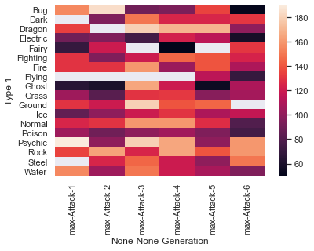

```python
### test if heatmap would look ok
sns.heatmap(get_summary(['Attack'],'max'))
```

## more pivot

```python
##make a fucntion that will aggregate my data based on whatever aggfun I want

get_summary(['Attack'],'min')
```

| Generation Type 1 | min Attack 1 | min Attack 2 | min Attack 3 | min Attack 4 | min Attack 5 | min Attack 6 |
| --- | --- | --- | --- | --- | --- | --- |
| Bug | 20.0 | 10.0 | 30.0 | 25.0 | 40.0 | 22.0 |
| Dark | NaN | 60.0 | 55.0 | 90.0 | 50.0 | 54.0 |
| Dragon | 64.0 | NaN | 70.0 | 70.0 | 87.0 | 50.0 |
| Electric | 30.0 | 40.0 | 40.0 | 45.0 | 55.0 | 38.0 |
| Fairy | 45.0 | 20.0 | NaN | 50.0 | NaN | 38.0 |
| Fighting | 80.0 | 35.0 | 40.0 | 70.0 | 80.0 | 82.0 |
| Fire | 41.0 | 40.0 | 60.0 | 58.0 | 30.0 | 45.0 |
| Flying | NaN | NaN | NaN | NaN | 100.0 | 30.0 |
| Ghost | 35.0 | 60.0 | 40.0 | 50.0 | 30.0 | 66.0 |
| Grass | 40.0 | 30.0 | 40.0 | 30.0 | 27.0 | 61.0 |
| Ground | 50.0 | 60.0 | 40.0 | 72.0 | 66.0 | NaN |
| Ice | 50.0 | 30.0 | 40.0 | 60.0 | 50.0 | 69.0 |
| Normal | 5.0 | 10.0 | 20.0 | 5.0 | 50.0 | 36.0 |
| Poison | 45.0 | 90.0 | 43.0 | 50.0 | 50.0 | 60.0 |
| Psychic | 20.0 | 33.0 | 23.0 | 25.0 | 25.0 | 48.0 |
| Rock | 40.0 | 64.0 | 41.0 | 42.0 | 75.0 | 50.0 |
| Steel | NaN | 80.0 | 55.0 | 24.0 | 55.0 | 50.0 |
| Water | 10.0 | 20.0 | 15.0 | 20.0 | 40.0 | 53.0 |

```python
##make a fucntion that will aggregate my data based on whatever aggfun I want

get_summary(['Attack','Speed'],('min','max'))
```

| Generation Type 1 | min max Attack 1 | min max Attack 2 | min max Attack 3 | min max Attack 4 | min max Attack 5 | min max Attack 6 | min max Attack 1 | min max Attack 2 | min max Attack 3 | min max Attack 4 | min max ... | min max Speed 3 | min max Speed 4 | min max Speed 5 | min max Speed 6 | min max Speed 1 | min max Speed 2 | min max Speed 3 | min max Speed 4 | min max Speed 5 | min max Speed 6 |
| --- | --- | --- | --- | --- | --- | --- | --- | --- | --- | --- | --- | --- | --- | --- | --- | --- | --- | --- | --- | --- | --- |
| Bug | 155.0 | 185.0 | 90.0 | 94.0 | 135.0 | 52.0 | 20.0 | 10.0 | 30.0 | 25.0 | ... | 160.0 | 95.0 | 145.0 | 89.0 | 25.0 | 5.0 | 15.0 | 25.0 | 20.0 | 29.0 |
| Dark | NaN | 95.0 | 150.0 | 125.0 | 125.0 | 131.0 | NaN | 60.0 | 55.0 | 90.0 | ... | 115.0 | 125.0 | 106.0 | 99.0 | NaN | 65.0 | 20.0 | 71.0 | 38.0 | 45.0 |
| Dragon | 134.0 | NaN | 180.0 | 170.0 | 170.0 | 100.0 | 64.0 | NaN | 70.0 | 70.0 | ... | 120.0 | 102.0 | 97.0 | 95.0 | 50.0 | NaN | 50.0 | 42.0 | 48.0 | 40.0 |
| Electric | 90.0 | 95.0 | 75.0 | 123.0 | 115.0 | 58.0 | 30.0 | 40.0 | 40.0 | 45.0 | ... | 135.0 | 95.0 | 116.0 | 109.0 | 45.0 | 35.0 | 65.0 | 45.0 | 40.0 | 70.0 |
| Fairy | 70.0 | 120.0 | NaN | 50.0 | NaN | 131.0 | 45.0 | 20.0 | NaN | 50.0 | ... | NaN | 80.0 | NaN | 99.0 | 35.0 | 15.0 | NaN | 80.0 | NaN | 23.0 |
| Fighting | 130.0 | 95.0 | 120.0 | 145.0 | 140.0 | 124.0 | 80.0 | 35.0 | 40.0 | 70.0 | ... | 100.0 | 112.0 | 105.0 | 118.0 | 35.0 | 35.0 | 25.0 | 60.0 | 35.0 | 43.0 |
| Fire | 130.0 | 130.0 | 160.0 | 104.0 | 140.0 | 110.0 | 41.0 | 40.0 | 60.0 | 58.0 | ... | 100.0 | 108.0 | 101.0 | 126.0 | 60.0 | 20.0 | 20.0 | 61.0 | 45.0 | 60.0 |
| Flying | NaN | NaN | NaN | NaN | 115.0 | 70.0 | NaN | NaN | NaN | NaN | ... | NaN | NaN | 121.0 | 123.0 | NaN | NaN | NaN | NaN | 111.0 | 55.0 |
| Ghost | 65.0 | 60.0 | 165.0 | 120.0 | 55.0 | 110.0 | 35.0 | 60.0 | 40.0 | 50.0 | ... | 75.0 | 105.0 | 80.0 | 99.0 | 80.0 | 85.0 | 25.0 | 35.0 | 20.0 | 38.0 |
| Grass | 105.0 | 82.0 | 130.0 | 132.0 | 98.0 | 107.0 | 40.0 | 30.0 | 40.0 | 30.0 | ... | 145.0 | 127.0 | 116.0 | 68.0 | 30.0 | 30.0 | 30.0 | 30.0 | 10.0 | 38.0 |
| Ground | 130.0 | 120.0 | 180.0 | 140.0 | 145.0 | NaN | 50.0 | 60.0 | 40.0 | 72.0 | ... | 100.0 | 95.0 | 101.0 | NaN | 25.0 | 40.0 | 10.0 | 32.0 | 32.0 | NaN |
| Ice | 85.0 | 100.0 | 120.0 | 130.0 | 110.0 | 117.0 | 50.0 | 30.0 | 40.0 | 60.0 | ... | 100.0 | 110.0 | 105.0 | 28.0 | 85.0 | 50.0 | 25.0 | 65.0 | 40.0 | 28.0 |
| Normal | 125.0 | 130.0 | 160.0 | 160.0 | 128.0 | 80.0 | 5.0 | 10.0 | 20.0 | 5.0 | ... | 125.0 | 135.0 | 128.0 | 102.0 | 20.0 | 15.0 | 20.0 | 5.0 | 42.0 | 57.0 |
| Poison | 105.0 | 90.0 | 100.0 | 106.0 | 95.0 | 75.0 | 45.0 | 90.0 | 43.0 | 50.0 | ... | 65.0 | 95.0 | 75.0 | 44.0 | 25.0 | 130.0 | 40.0 | 50.0 | 65.0 | 30.0 |
| Psychic | 190.0 | 100.0 | 180.0 | 165.0 | 100.0 | 160.0 | 20.0 | 33.0 | 23.0 | 25.0 | ... | 180.0 | 115.0 | 114.0 | 104.0 | 42.0 | 33.0 | 23.0 | 45.0 | 20.0 | 68.0 |
| Rock | 135.0 | 164.0 | 125.0 | 165.0 | 140.0 | 160.0 | 40.0 | 64.0 | 41.0 | 42.0 | ... | 75.0 | 58.0 | 110.0 | 110.0 | 20.0 | 30.0 | 23.0 | 10.0 | 15.0 | 46.0 |
| Steel | NaN | 125.0 | 145.0 | 120.0 | 100.0 | 150.0 | NaN | 80.0 | 55.0 | 24.0 | ... | 110.0 | 90.0 | 108.0 | 75.0 | NaN | 30.0 | 30.0 | 23.0 | 30.0 | 28.0 |
| Water | 155.0 | 105.0 | 150.0 | 120.0 | 108.0 | 95.0 | 10.0 | 20.0 | 15.0 | 20.0 | ... | 105.0 | 115.0 | 108.0 | 122.0 | 15.0 | 15.0 | 30.0 | 34.0 | 22.0 | 44.0 |

18 rows × 24 columns

## more on groupby--Skip in class--

We can accomplish the same results with groupby but in my opinion it is less intuitive than pivot table. I wrote the code below to introduce you to group by, it is by no means comprehensive but it will give you a place to start.

```python
## we can achive something similar with groupby
## in my experience I use pivot tables when I want one agg func and groupby when I want multiple agg funcs
## you can achive the same level of data analysis with pivot and groupby, you just have to find what works for you

def get_summary2(stat_wanted,aggfun_wanted):
  ###step 1, aggregare by type 1 and generation
  #data_subset=pokemon.groupby(['Type 1','Generation']).agg(aggfun_wanted)
  ### step 2 select the column with the stat we want
  #data_subset=pokemon.groupby(['Type 1','Generation'])[stat_wanted].agg(aggfun_wanted)
  ##clean up the index
    data_subset=pokemon.groupby(['Type 1','Generation'])[stat_wanted].agg(aggfun_wanted)
    return data_subset

get_summary2('Attack',['mean'])
```

| Type 1 | Generation | mean |
| --- | --- | --- |
| Bug | 1 | 76.428571 |
|  | 2 | 85.416667 |
|  | 3 | 55.833333 |
|  | 4 | 62.600000 |
|  | 5 | 77.611111 |
| ... | ... | ... |
| Water | 2 | 68.111111 |
|  | 3 | 80.666667 |
|  | 4 | 72.461538 |
|  | 5 | 73.277778 |
|  | 6 | 68.000000 |

98 rows × 1 columns

```python
## we can achive something similar with groupby

def get_summary2(stat_wanted,aggfun_wanted):
  ##note that with groupby you can include more columns in stats wanted and more aggfun arguments
    data_subset=pokemon.groupby(['Type 1','Generation'])[stat_wanted].agg(aggfun_wanted)
    return data_subset

get_summary2(['Attack','Speed'],['max','min'])
```

| Type 1 | Generation | Attack max | Attack min | Speed max | Speed min |
| --- | --- | --- | --- | --- | --- |
| Bug | 1 | 155 | 20 | 145 | 25 |
|  | 2 | 185 | 10 | 95 | 5 |
|  | 3 | 90 | 30 | 160 | 15 |
|  | 4 | 94 | 25 | 95 | 25 |
|  | 5 | 135 | 40 | 145 | 20 |
| ... | ... | ... | ... | ... | ... |
| Water | 2 | 105 | 20 | 85 | 15 |
|  | 3 | 150 | 15 | 105 | 30 |
|  | 4 | 120 | 20 | 115 | 34 |
|  | 5 | 108 | 40 | 108 | 22 |
|  | 6 | 95 | 53 | 122 | 44 |

98 rows × 4 columns

more info on [unstack](https://scentellegher.github.io/programming/2017/07/15/pandas-groupby-multiple-columns-plot.html)

```python
## we can achive something similar with groupby
## and groupby allows us to have more aggfunctions that pivot table

def get_summary2(stat_wanted,aggfun_wanted):
  ##note that with groupby you can include more columns in stats wanted and more aggfun arguments
  ##however the resulting dataframe has a multi index that makes plotting more dififcult
  ## we can go back to one index by doing unstack
    data_subset=pokemon.groupby(['Type 1','Generation'])[stat_wanted].agg(aggfun_wanted).unstack()
    return data_subset

get_summary2(['Attack','Speed'],['max','min'])
```

| Generation Type 1 | Attack max 1 | Attack max 2 | Attack max 3 | Attack max 4 | Attack max 5 | Attack max 6 | Attack min 1 | Attack min 2 | Attack min 3 | Attack min 4 | ... | Speed max 3 | Speed max 4 | Speed max 5 | Speed max 6 | Speed min 1 | Speed min 2 | Speed min 3 | Speed min 4 | Speed min 5 | Speed min 6 |
| --- | --- | --- | --- | --- | --- | --- | --- | --- | --- | --- | --- | --- | --- | --- | --- | --- | --- | --- | --- | --- | --- |
| Bug | 155.0 | 185.0 | 90.0 | 94.0 | 135.0 | 52.0 | 20.0 | 10.0 | 30.0 | 25.0 | ... | 160.0 | 95.0 | 145.0 | 89.0 | 25.0 | 5.0 | 15.0 | 25.0 | 20.0 | 29.0 |
| Dark | NaN | 95.0 | 150.0 | 125.0 | 125.0 | 131.0 | NaN | 60.0 | 55.0 | 90.0 | ... | 115.0 | 125.0 | 106.0 | 99.0 | NaN | 65.0 | 20.0 | 71.0 | 38.0 | 45.0 |
| Dragon | 134.0 | NaN | 180.0 | 170.0 | 170.0 | 100.0 | 64.0 | NaN | 70.0 | 70.0 | ... | 120.0 | 102.0 | 97.0 | 95.0 | 50.0 | NaN | 50.0 | 42.0 | 48.0 | 40.0 |
| Electric | 90.0 | 95.0 | 75.0 | 123.0 | 115.0 | 58.0 | 30.0 | 40.0 | 40.0 | 45.0 | ... | 135.0 | 95.0 | 116.0 | 109.0 | 45.0 | 35.0 | 65.0 | 45.0 | 40.0 | 70.0 |
| Fairy | 70.0 | 120.0 | NaN | 50.0 | NaN | 131.0 | 45.0 | 20.0 | NaN | 50.0 | ... | NaN | 80.0 | NaN | 99.0 | 35.0 | 15.0 | NaN | 80.0 | NaN | 23.0 |
| Fighting | 130.0 | 95.0 | 120.0 | 145.0 | 140.0 | 124.0 | 80.0 | 35.0 | 40.0 | 70.0 | ... | 100.0 | 112.0 | 105.0 | 118.0 | 35.0 | 35.0 | 25.0 | 60.0 | 35.0 | 43.0 |
| Fire | 130.0 | 130.0 | 160.0 | 104.0 | 140.0 | 110.0 | 41.0 | 40.0 | 60.0 | 58.0 | ... | 100.0 | 108.0 | 101.0 | 126.0 | 60.0 | 20.0 | 20.0 | 61.0 | 45.0 | 60.0 |
| Flying | NaN | NaN | NaN | NaN | 115.0 | 70.0 | NaN | NaN | NaN | NaN | ... | NaN | NaN | 121.0 | 123.0 | NaN | NaN | NaN | NaN | 111.0 | 55.0 |
| Ghost | 65.0 | 60.0 | 165.0 | 120.0 | 55.0 | 110.0 | 35.0 | 60.0 | 40.0 | 50.0 | ... | 75.0 | 105.0 | 80.0 | 99.0 | 80.0 | 85.0 | 25.0 | 35.0 | 20.0 | 38.0 |
| Grass | 105.0 | 82.0 | 130.0 | 132.0 | 98.0 | 107.0 | 40.0 | 30.0 | 40.0 | 30.0 | ... | 145.0 | 127.0 | 116.0 | 68.0 | 30.0 | 30.0 | 30.0 | 30.0 | 10.0 | 38.0 |
| Ground | 130.0 | 120.0 | 180.0 | 140.0 | 145.0 | NaN | 50.0 | 60.0 | 40.0 | 72.0 | ... | 100.0 | 95.0 | 101.0 | NaN | 25.0 | 40.0 | 10.0 | 32.0 | 32.0 | NaN |
| Ice | 85.0 | 100.0 | 120.0 | 130.0 | 110.0 | 117.0 | 50.0 | 30.0 | 40.0 | 60.0 | ... | 100.0 | 110.0 | 105.0 | 28.0 | 85.0 | 50.0 | 25.0 | 65.0 | 40.0 | 28.0 |
| Normal | 125.0 | 130.0 | 160.0 | 160.0 | 128.0 | 80.0 | 5.0 | 10.0 | 20.0 | 5.0 | ... | 125.0 | 135.0 | 128.0 | 102.0 | 20.0 | 15.0 | 20.0 | 5.0 | 42.0 | 57.0 |
| Poison | 105.0 | 90.0 | 100.0 | 106.0 | 95.0 | 75.0 | 45.0 | 90.0 | 43.0 | 50.0 | ... | 65.0 | 95.0 | 75.0 | 44.0 | 25.0 | 130.0 | 40.0 | 50.0 | 65.0 | 30.0 |
| Psychic | 190.0 | 100.0 | 180.0 | 165.0 | 100.0 | 160.0 | 20.0 | 33.0 | 23.0 | 25.0 | ... | 180.0 | 115.0 | 114.0 | 104.0 | 42.0 | 33.0 | 23.0 | 45.0 | 20.0 | 68.0 |
| Rock | 135.0 | 164.0 | 125.0 | 165.0 | 140.0 | 160.0 | 40.0 | 64.0 | 41.0 | 42.0 | ... | 75.0 | 58.0 | 110.0 | 110.0 | 20.0 | 30.0 | 23.0 | 10.0 | 15.0 | 46.0 |
| Steel | NaN | 125.0 | 145.0 | 120.0 | 100.0 | 150.0 | NaN | 80.0 | 55.0 | 24.0 | ... | 110.0 | 90.0 | 108.0 | 75.0 | NaN | 30.0 | 30.0 | 23.0 | 30.0 | 28.0 |
| Water | 155.0 | 105.0 | 150.0 | 120.0 | 108.0 | 95.0 | 10.0 | 20.0 | 15.0 | 20.0 | ... | 105.0 | 115.0 | 108.0 | 122.0 | 15.0 | 15.0 | 30.0 | 34.0 | 22.0 | 44.0 |

18 rows × 24 columns

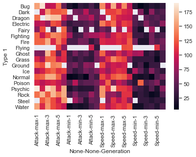

```python
sns.heatmap(get_summary2(['Attack','Speed'],['max','min']))
```

## 14.2 Automate graph making

I really want to create a way to visualize the different stats and figure out what the strongest/weakest pokemon types and pokemon are.

STEP1. I want to make many heatplots to view diff stats so I want to write my code below in such a way that will allow me to do that.

```python
for place_in_list,i in enumerate(pokemon.columns):
    print (place_in_list,i)
```

```
0 Number
1 Name
2 Type 1
3 Type 2
4 Total
5 HP
6 Attack
7 Defense
8 Sp. Atk
9 Sp. Def
10 Speed
11 Generation
12 Legendary
```

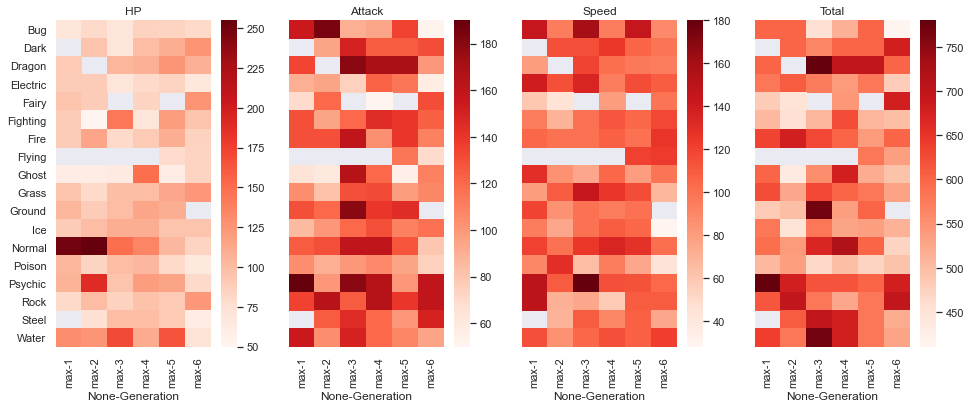

```python
## let's make a list that will hold the variables I want
## when I change the contents of my list the rest of my code will react accordingly
stats_all=['HP','Attack','Speed','Total']

##call a figure object that always has 1 row but the columns change based on the contents of my list
fig, ax=plt.subplots(nrows=1,ncols=len(stats_all),sharey=True)

#change the figure size by the lenth of my list so my figure is always pretty
fig.set_size_inches(len(stats_all)*4,6)

for count,stat in enumerate(stats_all):
  #print (count,stat)
  ## I'm going to use the output from my function that uses pivot table but you can you anything
    hold=get_summary(stat,'max')
    sns.heatmap(hold,ax=ax[count],cmap="Reds")
    ax[count].set_ylabel('')
    ax[count].set_title(f'{stat}')
```

```python
def get_heat(stats_all,aggfunction_wanted):

    ## let's make a list that will hold the variables I want
    ## when I change the contents of my list the rest of my code will react accordingly

    ##call a figure object that always has 1 row but the columns change based on the contents of my list
    fig, ax=plt.subplots(nrows=1,ncols=len(stats_all),sharey=True)

    #change the figure size by the lenth of my list so my figure is always pretty
    fig.set_size_inches(len(stats_all*4),6)

    for count,stat in enumerate(stats_all):
        #print (count,stat)
        hold=get_summary(stat,aggfunction_wanted)
        sns.heatmap(hold,ax=ax[count],cmap="Reds")
        ax[count].set_ylabel('')
        ax[count].set_title(f'{stat}')

plt.show()
```

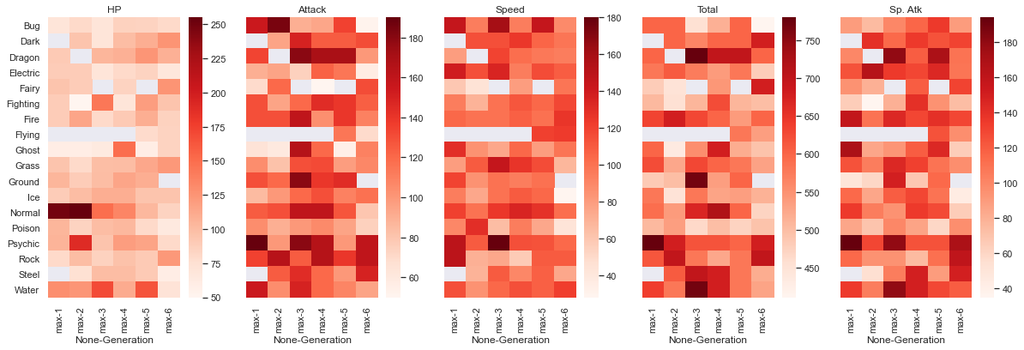

```python
##cool now we can explore the different pokemon stats based on diff math stats
get_heat(stats_all=['HP','Attack','Speed','Total','Sp. Atk'],aggfunction_wanted='max')
```

```python
## make a function that quickly lets me view pokemons based on Type 1 and Generation

def get_pokemon(type_1,generation,stat_wanted):
    out=pokemon.loc[((pokemon['Type 1']== type_1)&(pokemon['Generation']==generation))].copy()
    out.sort_values(by=stat_wanted,ascending=False,inplace=True)
    return out

get_pokemon('Psychic',1,'Attack')
```

|  | Number | Name | Type 1 | Type 2 | Total | HP | Attack | Defense | Sp. Atk | Sp. Def | Speed | Generation | Legendary |
| --- | --- | --- | --- | --- | --- | --- | --- | --- | --- | --- | --- | --- | --- |
| 163 | 150 | MewtwoMega Mewtwo X | Psychic | Fighting | 780 | 106 | 190 | 100 | 154 | 100 | 130 | 1 | True |
| 164 | 150 | MewtwoMega Mewtwo Y | Psychic | NaN | 780 | 106 | 150 | 70 | 194 | 120 | 140 | 1 | True |
| 162 | 150 | Mewtwo | Psychic | NaN | 680 | 106 | 110 | 90 | 154 | 90 | 130 | 1 | True |
| 165 | 151 | Mew | Psychic | NaN | 600 | 100 | 100 | 100 | 100 | 100 | 100 | 1 | False |
| 105 | 97 | Hypno | Psychic | NaN | 483 | 85 | 73 | 70 | 73 | 115 | 67 | 1 | False |
| 70 | 65 | Alakazam | Psychic | NaN | 500 | 55 | 50 | 45 | 135 | 95 | 120 | 1 | False |
| 71 | 65 | AlakazamMega Alakazam | Psychic | NaN | 590 | 55 | 50 | 65 | 175 | 95 | 150 | 1 | False |
| 104 | 96 | Drowzee | Psychic | NaN | 328 | 60 | 48 | 45 | 43 | 90 | 42 | 1 | False |
| 131 | 122 | Mr. Mime | Psychic | Fairy | 460 | 40 | 45 | 65 | 100 | 120 | 90 | 1 | False |
| 69 | 64 | Kadabra | Psychic | NaN | 400 | 40 | 35 | 30 | 120 | 70 | 105 | 1 | False |
| 68 | 63 | Abra | Psychic | NaN | 310 | 25 | 20 | 15 | 105 | 55 | 90 | 1 | False |

## Conclusion:

Pandas will help you clean, order and analyze your data. Then you can use libraries like seaborn so make figures for your manuscripts.

Google and stackoverflow are your friends, use them! Also YOUTUBE is a gold mine. [This](https://www.youtube.com/c/dataschool/videos) is on of my favorite channels but explore and find your own!

# RUN THE REST OF CODE AND SHOW GRAPHS

## 15. Extra: Combination skills, Correlations

## Scatter plots

I want to know what stats values are highly correlated. So I am going to use [sns.regplot](https://seaborn.pydata.org/generated/seaborn.regplot.html)

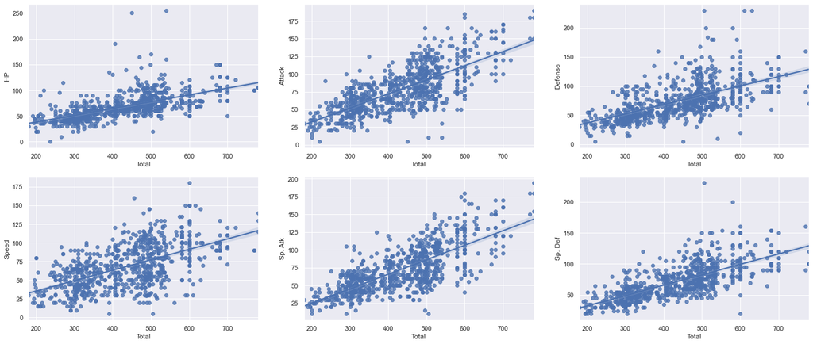

```python
## not specifying how many subplots I want will allow me to add subplots with the for loop
fig = plt.figure()

fig.subplots_adjust(hspace=0.2, wspace=0.2)

## this list can change but it muts always change by the nrow value you specify in the for loop
stats_all=['HP','Attack','Defense','Speed','Sp. Atk','Sp. Def']
fig.set_size_inches(len(stats_all*4),10)

for count,stat in enumerate(stats_all):
    ax = fig.add_subplot(2, 3, count+1)
    ax=sns.regplot(x='Total', y=stat, data=pokemon)

plt.show()
plt.close()
```

Cool figure, let's add some labels so we can read it better

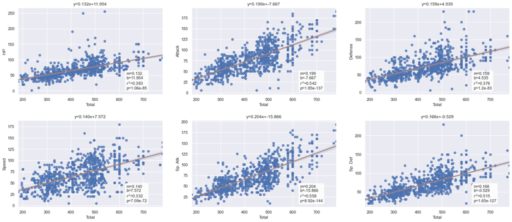

```python
fig = plt.figure()

z = len(stats_all)/2 #this variable is classified as a floating point number, we need to change it to an integer.

fig.subplots_adjust(hspace=0.3, wspace=0.2)

stats_all=['HP','Attack','Defense','Speed','Sp. Atk','Sp. Def']
fig.set_size_inches(len(stats_all*4),10)

for count,stat in enumerate(stats_all):
    ax = fig.add_subplot(2, int(z), count+1)
    ax=sns.regplot(x='Total', y=stat, data=pokemon)

    ##get stats for a label
    temp=pokemon[['Total',stat]].dropna()
    results=stats.linregress(temp.iloc[:,0],temp.iloc[:,1])
    #print (results)

    ##this code makes the labels in the box
    props=dict(boxstyle='round',facecolor='white',alpha=.9)
    textstr='m={:.3f}\nb={:.3f}\n$r^2$={:.3f}\np={:.3}'.format(results[0],results[1],results[2]**2,results[3]) #grabs the values from stats_out
    ax.text(.75,.05,textstr,transform=ax.transAxes,va='bottom',fontsize=11,bbox=props) #change the formatting of the box

    #this code here allows me to make a line manually
    x1=np.array([temp.Total.min(),temp.Total.max()])
    y1=results[0]*x1+results[1]
    ax.plot(x1,y1)

    ## add line equation as a title
    m=results[0]
    b=results[1]
    ax.set_title('y={:.3f}x+{:.3f}'.format(m,b))


plt.show()
plt.close()
```

Let's make the code into a function so we can easily change what we plot

```python
def correlates_with_wanted(stats_wanted):

    fig = plt.figure()
    fig.subplots_adjust(hspace=0.3, wspace=0.2)

    stats_all=['HP','Attack','Defense','Speed','Sp. Atk','Sp. Def','Total']
    stats_all.remove(stats_wanted)
    fig.set_size_inches(len(stats_all*4),10)

    for count,stat in enumerate(stats_all):
        # remeber that add_subplots is (nrow,ncol,number) and number starts at 1 while enumerate at 0
        ax = fig.add_subplot(2, int(z), count+1)
        ax=sns.regplot(x=stats_wanted, y=stat, data=pokemon)

        ##get stats for a label
        temp=pokemon[[stats_wanted,stat]].dropna()
        results=stats.linregress(temp.iloc[:,0],temp.iloc[:,1])
        #print (results)

        props=dict(boxstyle='round',facecolor='white',alpha=.9)
        textstr='m={:.3f}\nb={:.3f}\n$r^2$={:.3f}\np={:.3}'.format(results[0],results[1],results[2]**2,results[3]) #grabs the values from stats_out
        ax.text(.75,.05,textstr,transform=ax.transAxes,va='bottom',fontsize=11,bbox=props) #change the formatting of the box

        #this code here woul allow to make a line manually
        x1=np.array([temp[stats_wanted].min(),temp[stats_wanted].max()])
        y1=results[0]*x1+results[1]
        ax.plot(x1,y1)

        ## add line equation as a title
        m=results[0]
        b=results[1]
        ax.set_title('y={:.3f}x+{:.3f}'.format(m,b))


plt.show()
plt.close()

correlates_with_wanted('Defense')
```

[output not shown]

## Table of correlations

```python
### make a table of correlations

stats_all=['HP','Attack','Defense','Speed','Sp. Atk','Sp. Def','Total']

stats_df=pd.DataFrame(index=stats_all,columns=stats_all)

for i in stats_all:
    for k in stats_all:
        stats_results=stats.linregress(pokemon[i],pokemon[k])
        #print(stats_results)
        stats_df[i][k]=stats_results[2].round(2)

stats_df
```

|  | HP | Attack | Defense | Speed | Sp. Atk | Sp. Def | Total |
| --- | --- | --- | --- | --- | --- | --- | --- |
| HP | 1.0 | 0.42 | 0.24 | 0.18 | 0.36 | 0.38 | 0.62 |
| Attack | 0.42 | 1.0 | 0.44 | 0.38 | 0.4 | 0.26 | 0.74 |
| Defense | 0.24 | 0.44 | 1.0 | 0.02 | 0.22 | 0.51 | 0.61 |
| Speed | 0.18 | 0.38 | 0.02 | 1.0 | 0.47 | 0.26 | 0.58 |
| Sp. Atk | 0.36 | 0.4 | 0.22 | 0.47 | 1.0 | 0.51 | 0.75 |
| Sp. Def | 0.38 | 0.26 | 0.51 | 0.26 | 0.51 | 1.0 | 0.72 |
| Total | 0.62 | 0.74 | 0.61 | 0.58 | 0.75 | 0.72 | 1.0 |

```python
### a faster trick
corr_all=pokemon.corr()
corr_all
```

|  | Number | Total | HP | Attack | Defense | Sp. Atk | Sp. Def | Speed | Generation | Legendary |
| --- | --- | --- | --- | --- | --- | --- | --- | --- | --- | --- |
| Number | 1.000000 | 0.119813 | 0.097614 | 0.102298 | 0.094786 | 0.088759 | 0.085817 | 0.010733 | 0.982516 | 0.153396 |
| Total | 0.119813 | 1.000000 | 0.618748 | 0.736211 | 0.612787 | 0.747250 | 0.717609 | 0.575943 | 0.048384 | 0.501758 |
| HP | 0.097614 | 0.618748 | 1.000000 | 0.422386 | 0.239622 | 0.362380 | 0.378718 | 0.175952 | 0.058683 | 0.273620 |
| Attack | 0.102298 | 0.736211 | 0.422386 | 1.000000 | 0.438687 | 0.396362 | 0.263990 | 0.381240 | 0.051451 | 0.345408 |
| Defense | 0.094786 | 0.612787 | 0.239622 | 0.438687 | 1.000000 | 0.223549 | 0.510747 | 0.015227 | 0.042419 | 0.246377 |
| Sp. Atk | 0.088759 | 0.747250 | 0.362380 | 0.396362 | 0.223549 | 1.000000 | 0.506121 | 0.473018 | 0.036437 | 0.448907 |
| Sp. Def | 0.085817 | 0.717609 | 0.378718 | 0.263990 | 0.510747 | 0.506121 | 1.000000 | 0.259133 | 0.028486 | 0.363937 |
| Speed | 0.010733 | 0.575943 | 0.175952 | 0.381240 | 0.015227 | 0.473018 | 0.259133 | 1.000000 | -0.023121 | 0.326715 |
| Generation | 0.982516 | 0.048384 | 0.058683 | 0.051451 | 0.042419 | 0.036437 | 0.028486 | -0.023121 | 1.000000 | 0.079794 |
| Legendary | 0.153396 | 0.501758 | 0.273620 | 0.345408 | 0.246377 | 0.448907 | 0.363937 | 0.326715 | 0.079794 | 1.000000 |

## Density plots

Once you have code that works all you need to do is change the plot kind and it will work

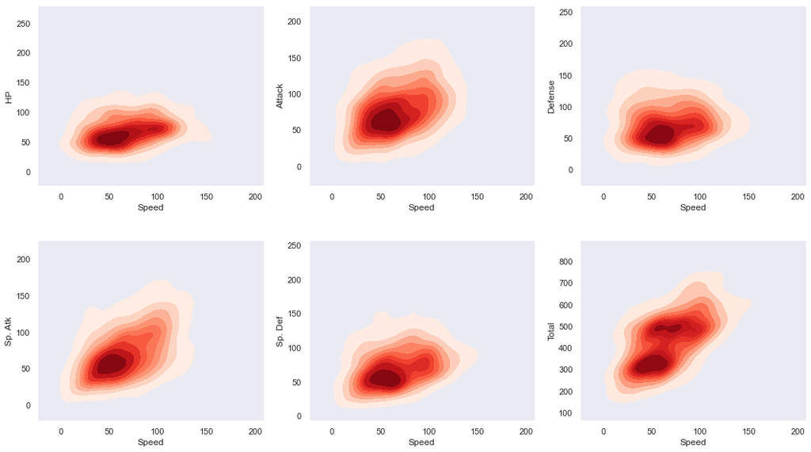

```python
sns.set(style="dark")

def density_with_wanted(stats_wanted):

    fig = plt.figure()
    fig.subplots_adjust(hspace=0.3, wspace=0.2)

    stats_all=['HP','Attack','Defense','Speed','Sp. Atk','Sp. Def','Total']
    stats_all.remove(stats_wanted)

    fig.set_size_inches(len(stats_all*3),10)

    for count,stat in enumerate(stats_all):
        # remeber that add_subplots is (nrow,ncol,number) and number starts at 1 while enumerate at 0
        ax = fig.add_subplot(2, int(z), count+1)
        ##change the kind of figure you want
        sns.kdeplot(x=pokemon[stats_wanted], y=pokemon[stat], cmap='Reds', shade=True, ax=ax)

plt.show()
plt.close()

density_with_wanted('Speed')
```

we can make the function a little more complicated by adding in another for loop. This will make it so that each subplots has multiple plots inside.

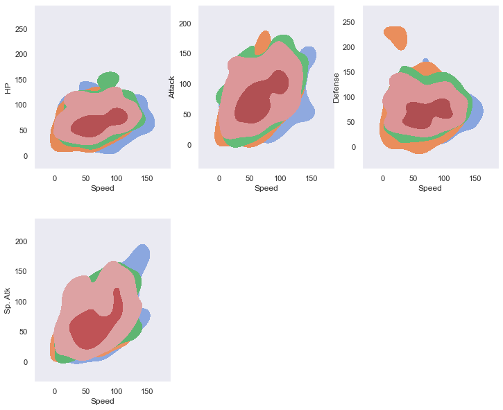

```python
sns.set(style="dark")

def density_with_wanted(stats_wanted):

    fig = plt.figure()
    fig.subplots_adjust(hspace=0.3, wspace=0.2)

    stats_all=['HP','Attack','Defense','Speed','Sp. Atk']
    stats_all.remove(stats_wanted)

    fig.set_size_inches(len(stats_all*3),10)

    for count,stat in enumerate(stats_all):
        # remeber that add_subplots is (nrow,ncol,number) and number starts at 1 while enumerate at 0
        ax = fig.add_subplot(2, int(z), count+1)

        for gen in [1,2,4,5]:
            pokemon_subset=pokemon.loc[pokemon['Generation']==gen]
            #x,y=pokemon_subset[stats_wanted],pokemon_subset[stat]
            sns.kdeplot(x=pokemon_subset[stats_wanted], y=pokemon_subset[stat], shade=True, ax=ax,thresh=0.05, n_levels=3)

plt.show()
plt.close()

density_with_wanted('Speed')
```

## 16. Extra: Data exploration

Once you have cleaned up your datatable it is really easy to plot. You just look for the kind of plot you want and specify the data you want. You can play around with the variables until you get something meaningful.

## Pairplots

Like the plots we manually made above, [Pairplot](https://seaborn.pydata.org/generated/seaborn.pairplot.html) allows you to see relationships between variables.

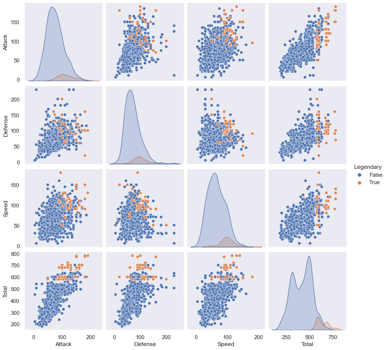

```python
sns.pairplot(pokemon[['Type 1','Attack','Defense','Speed','Total','Legendary']],hue='Legendary')
```

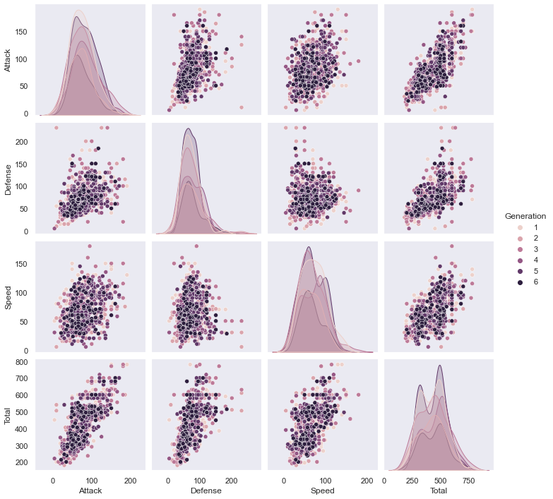

```python
sns.pairplot(pokemon[['Type 1','Attack','Defense','Speed','Total','Generation']],hue='Generation')
```

```python
pokemon['generation_legend']=pokemon['Generation'].astype(str)+'_'+pokemon['Legendary'].astype(str)
pokemon.head()
```

|  | Number | Name | Type 1 | Type 2 | Total | HP | Attack | Defense | Sp. Atk | Sp. Def | Speed | Generation | Legendary | generation_legend |
| --- | --- | --- | --- | --- | --- | --- | --- | --- | --- | --- | --- | --- | --- | --- |
| 0 | 1 | Bulbasaur | Grass | Poison | 318 | 45 | 49 | 49 | 65 | 65 | 45 | 1 | False | 1_False |
| 1 | 2 | Ivysaur | Grass | Poison | 405 | 60 | 62 | 63 | 80 | 80 | 60 | 1 | False | 1_False |
| 2 | 3 | Venusaur | Grass | Poison | 525 | 80 | 82 | 83 | 100 | 100 | 80 | 1 | False | 1_False |
| 3 | 3 | VenusaurMega Venusaur | Grass | Poison | 625 | 80 | 100 | 123 | 122 | 120 | 80 | 1 | False | 1_False |
| 4 | 4 | Charmander | Fire | NaN | 309 | 39 | 52 | 43 | 60 | 50 | 65 | 1 | False | 1_False |

let's make our new figure, and change some details using [palette](https://matplotlib.org/3.2.1/tutorials/colors/colormaps.html)

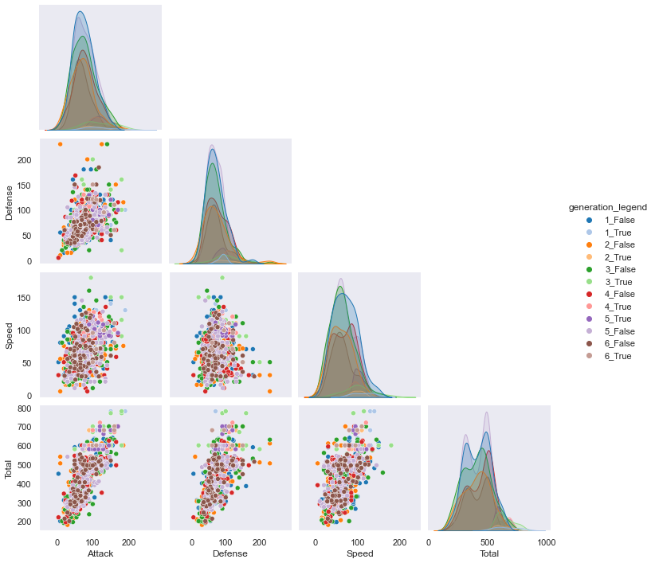

```python
sns.pairplot(pokemon[['Type 1','Attack','Defense','Speed','Total','generation_legend']],hue='generation_legend',palette='tab20',corner=True,)
```

## Swarmplots

I wanted to explore the Legendary distrubution more so I looked in seaborn to see what kinds of plots are used for categorical data and swarmplots came up.

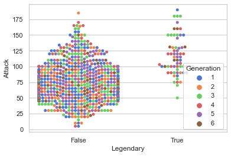

```python
##this calls the style of the plot
sns.set(style="whitegrid", palette="muted")

#this calls the actual swarmplot
sns.swarmplot(x="Legendary", y="Attack", hue="Generation", data=pokemon)

#you will get a warning that some of the plots can't be placed, this is ok because it's just an example.
```

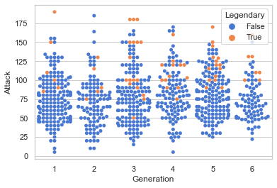

```python
sns.swarmplot(x="Generation", y="Attack", hue="Legendary", data=pokemon)
```

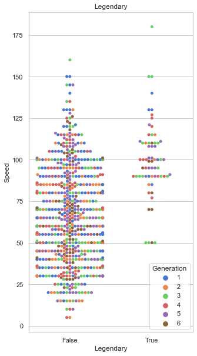

```python
fig, ax=plt.subplots()
fig.set_size_inches(5,10)

sns.swarmplot(x="Legendary", y="Speed", hue="Generation", data=pokemon,ax=ax)
ax.set_title('Legendary')

plt.savefig(data_out_directory+'swarm.pdf')
```

## Coding challenge

Here is the website on how to make [violinplots](https://seaborn.pydata.org/generated/seaborn.violinplot.html) with seaborn.

```python
#### using the full pokemon data
### make a violinplot where the x is Attack, y is Type 1, and hue is legendary
## remeber to change the figure size so the figure is readable
```

### Answer

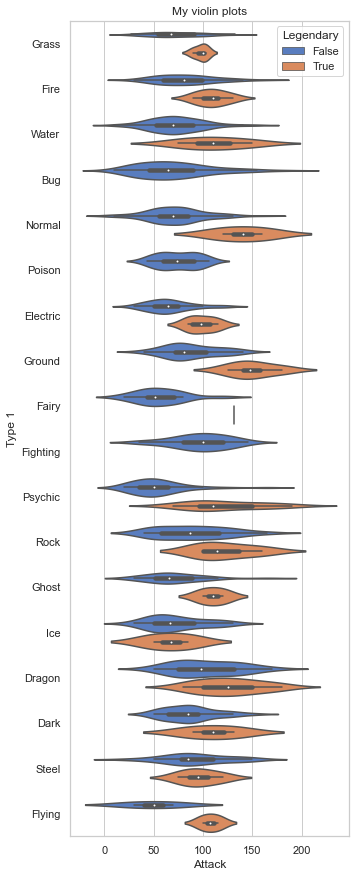

```python
#@title
fig, ax=plt.subplots()

fig.set_size_inches(5,15)

sns.violinplot(x="Attack", y="Type 1", data=pokemon, hue='Legendary',ax=ax)

ax.set_title('My violin plots')
```

# 17.Extra fun

THIS IS HOW YOU MAKE PLOTS

1. call figure and create your canvas ... fig, ax= plt.subplots()
2. follow instructions on websites for the actual plot you want ...some plot code
3. change some stuff ....ax.set_title('My plot title')
4. save the plot if you want... plt.savefig('My_plot')

## cluster with heatmap

more code [here](https://seaborn.pydata.org/generated/seaborn.clustermap.html)

```python
### let's select the legendary and work with those
pokemon_legend=pokemon.loc[pokemon['Legendary']==True,]
pokemon_legend
```

|  | Number | Name | Type 1 | Type 2 | Total | HP | Attack | Defense | Sp. Atk | Sp. Def | Speed | Generation | Legendary | generation_legend |
| --- | --- | --- | --- | --- | --- | --- | --- | --- | --- | --- | --- | --- | --- | --- |
| 156 | 144 | Articuno | Ice | Flying | 580 | 90 | 85 | 100 | 95 | 125 | 85 | 1 | True | 1_True |
| 157 | 145 | Zapdos | Electric | Flying | 580 | 90 | 90 | 85 | 125 | 90 | 100 | 1 | True | 1_True |
| 158 | 146 | Moltres | Fire | Flying | 580 | 90 | 100 | 90 | 125 | 85 | 90 | 1 | True | 1_True |
| 162 | 150 | Mewtwo | Psychic | NaN | 680 | 106 | 110 | 90 | 154 | 90 | 130 | 1 | True | 1_True |
| 163 | 150 | MewtwoMega Mewtwo X | Psychic | Fighting | 780 | 106 | 190 | 100 | 154 | 100 | 130 | 1 | True | 1_True |
| ... | ... | ... | ... | ... | ... | ... | ... | ... | ... | ... | ... | ... | ... | ... |
| 795 | 719 | Diancie | Rock | Fairy | 600 | 50 | 100 | 150 | 100 | 150 | 50 | 6 | True | 6_True |
| 796 | 719 | DiancieMega Diancie | Rock | Fairy | 700 | 50 | 160 | 110 | 160 | 110 | 110 | 6 | True | 6_True |
| 797 | 720 | HoopaHoopa Confined | Psychic | Ghost | 600 | 80 | 110 | 60 | 150 | 130 | 70 | 6 | True | 6_True |
| 798 | 720 | HoopaHoopa Unbound | Psychic | Dark | 680 | 80 | 160 | 60 | 170 | 130 | 80 | 6 | True | 6_True |
| 799 | 721 | Volcanion | Fire | Water | 600 | 80 | 110 | 120 | 130 | 90 | 70 | 6 | True | 6_True |

65 rows × 14 columns

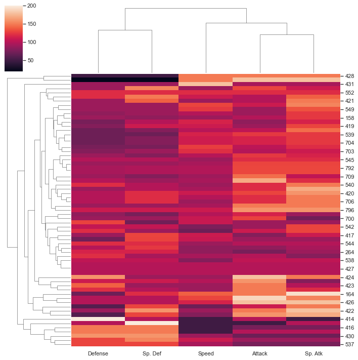

```python
sns.clustermap(pokemon_legend[['Attack','Defense','Speed','Sp. Atk','Sp. Def']])
```

## Venn Diagrams

I just googled python venn diagrams and searched through some of the pages that came out. more info [HERE](https://towardsdatascience.com/how-to-create-and-customize-venn-diagrams-in-python-263555527305)

```python
pip install matplotlib_venn
```

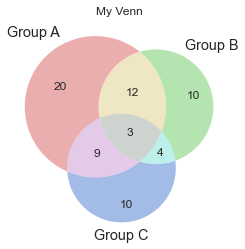

```python
from matplotlib_venn import venn3

# Make the diagram, code from the website I listed
## I'm just going to add some stuff the website did not show

#call figure and create your canvas
fig, ax= plt.subplots()

## follow instructions on website
venn3(subsets = (20, 10, 12, 10, 9, 4, 3), set_labels = ('Group A', 'Group B', 'Group C'), alpha = 0.5,ax=ax)

##change some stuff
ax.set_title('My Venn')

#save the plot if you want.
#plt.savefig('My_Venn')
```